# Health Spending and Life Expectancy Analysis - 2020

## Introduction

This report analyzes the relationship between health spending (as percentage of GDP) and life expectancy across countries, focusing on data from 2020. The analysis includes world map visualizations for each indicator and examines their relationship.

**Note**: The health spending dataset contains data up to 2010. For comparability, we will use 2020 data for life expectancy and 2010 data (most recent available) for health spending, as these represent the most recent data points available for comparison.

## Data Loading and Preparation

```
## Data Summary:

## - Countries with life expectancy data (2020): 193

## - Countries with health spending data (2010): 185

## - Countries in combined dataset: 185
```

## World Map Visualizations

### Life Expectancy in 2020

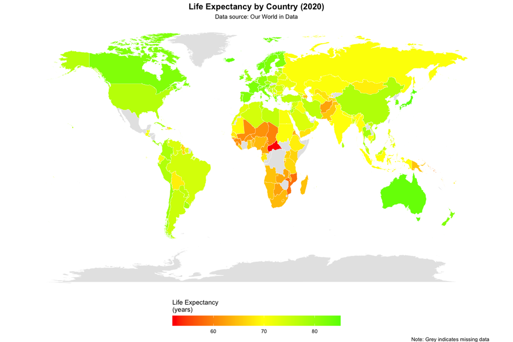

### Health Spending as % of GDP (2010 - Most Recent Available)

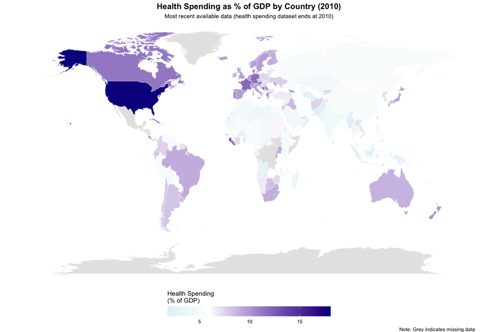

## Relationship Analysis

### Scatterplot: Health Spending vs Life Expectancy

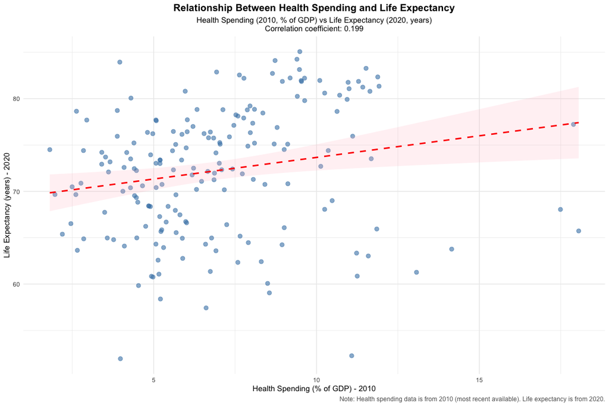

### Summary Statistics

| Statistic | Value |
| --- | --- |
| n_countries | 185.000 |
| mean_health_spending | 6.950 |
| median_health_spending | 6.590 |
| min_health_spending | 1.810 |
| max_health_spending | 18.050 |
| mean_life_expectancy | 72.240 |
| median_life_expectancy | 72.930 |
| min_life_expectancy | 51.950 |
| max_life_expectancy | 85.070 |
| correlation | 0.199 |

Summary Statistics

### Top Countries by Each Indicator

```
## ### Top 10 Countries by Life Expectancy (2020)
```

| Country | Life Expectancy (years) | Health Spending (% of GDP) |
| --- | --- | --- |
| Japan | 85.07 | 9.49 |
| Iceland | 84.25 | 9.40 |
| Australia | 84.11 | 8.73 |
| Singapore | 83.94 | 3.96 |
| Switzerland | 83.27 | 11.52 |
| Norway | 83.14 | 9.48 |
| South Korea | 82.87 | 6.93 |
| Malta | 82.72 | 8.65 |
| Israel | 82.55 | 7.63 |
| France | 82.34 | 11.88 |

Top 10 Countries by Life Expectancy (2020)

```
##
##
## ### Top 10 Countries by Health Spending (2010)
```

| Country | Health Spending (% of GDP) | Life Expectancy (years) |
| --- | --- | --- |
| Marshall Islands | 18.05 | 65.73 |
| USA | 17.89 | 77.22 |
| Tuvalu | 17.49 | 68.05 |
| Micronesia, Fed. Sts. | 14.15 | 63.77 |
| Sierra Leone | 13.07 | 61.27 |
| Netherlands | 11.92 | 81.34 |
| France | 11.88 | 82.34 |
| Liberia | 11.85 | 65.94 |
| Moldova | 11.68 | 73.52 |
| Germany | 11.64 | 80.79 |

Top 10 Countries by Health Spending (2010)

## Interpretation of the Relationship

### Key Findings

1. **Correlation Analysis**: The correlation coefficient between health spending (2010) and life expectancy (2020) is **0.199**, indicating a weak positive relationship between the two indicators.
2. **Geographic Patterns**:
   - **Life Expectancy (2020)**: The world map reveals clear regional patterns. Countries in Europe, North America, Australia, and parts of Asia tend to have higher life expectancy (typically above 75 years), while countries in sub-Saharan Africa generally show lower life expectancy (often below 65 years).
   - **Health Spending (2010)**: The map shows that developed countries, particularly in North America and Western Europe, allocate a larger percentage of their GDP to health spending (often above 8-10%), while many developing countries spend less than 5% of GDP on healthcare.
3. **Relationship Interpretation**:
   - The positive correlation suggests that, on average, countries that spend more on healthcare as a percentage of GDP tend to have higher life expectancy. However, the relationship is not particularly strong, indicating that health spending is just one of many factors influencing life expectancy.
   - **Important caveats**:
     - The correlation is modest, suggesting that other factors such as public health infrastructure, sanitation, nutrition, education, economic development, and lifestyle factors also play crucial roles in determining life expectancy.
     - There are notable exceptions: some countries with relatively low health spending achieve good life expectancy through efficient healthcare systems, while some countries with high spending may have inefficiencies or other health challenges.
     - The time lag between health spending data (2010) and life expectancy (2020) should be considered, as health investments may take time to manifest in population health outcomes.
4. **Notable Observations**:
   - Some countries demonstrate high life expectancy despite moderate health spending, suggesting efficient healthcare delivery systems.
   - Conversely, some countries with high health spending may face challenges that prevent optimal health outcomes.
   - Regional patterns suggest that geographic, cultural, and socioeconomic factors beyond direct healthcare spending significantly influence population health.

## Feedback

In this exercise I worked entirely inside Cursor, using its AI assistance together with R code execution. Cursor made it easy to draft and refine the analysis steps in natural language and then turn them into R scripts. I was able to run R directly in the environment, but I still had to install and load some R libraries before the code could run, which reminded me that AI-generated code still depends on a properly set up environment. One practical challenge was that Cursor did not always persist key analytical parameters — for example, I had to re-state the year of analysis in a later prompt — so I learned to repeat critical context (year, country, dataset) whenever I moved to a new step. Overall, the combination of Cursor + R was productive: AI accelerated the writing and code scaffolding, while R provided the actual analysis and verification, with me staying in the loop to check outputs and fix missing packages.